# bak_lab12

Jakub Bąk

24 01 2021

# Zadania na 12 laboratorium: Analiza szeregów czasowych

Wczytanie danych i ich wyswietlenie

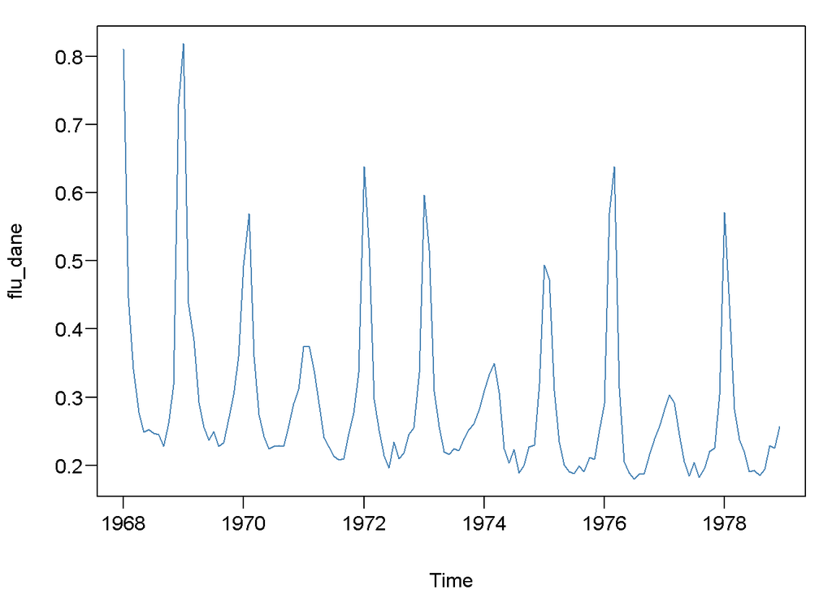

```r
library("astsa")
flu_dane <- flu
par(mar=c(4,4,1,1)+0.1, mgp=c(3,0.6,0),las=1)
plot(flu_dane,type="l",col="SteelBlue")
```

Przyklady szeregow

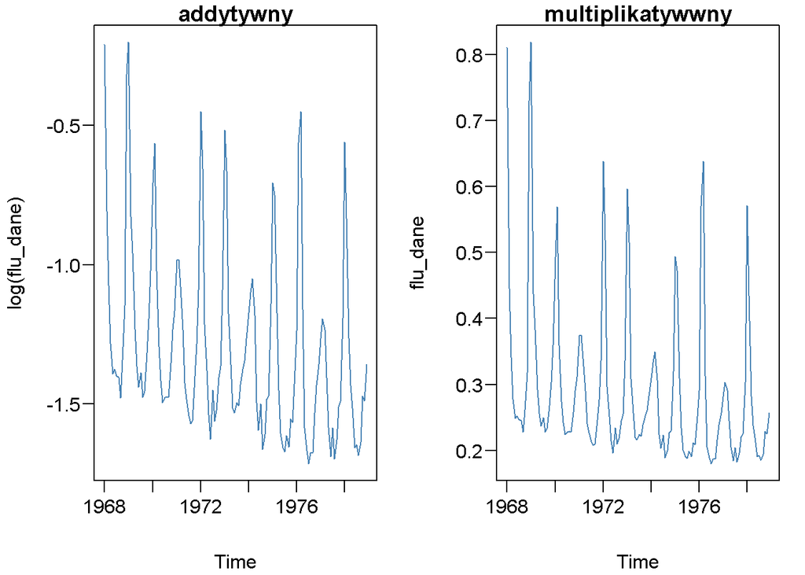

```r
par(mfcol=c(1,2),mar=c(4,4,1,1)+0.1, mgp=c(3,0.6,0),las=1)
plot(log(flu_dane),col="SteelBlue"); title("addytywny")
plot(flu_dane,col="SteelBlue"); title("multiplikatywwny")
```

Na poczatku narysowalem przykladowe szeregi czasowe, pokazujace trend. Jak mozemy zobaczyc, istnieje on w pewnej formie, ale zeby sie upewnic, nalezy usunac tendencje rozwojowa z procesu, co bedzie wykonane w nastepnej czesci.

Jednokrotne roznicowanie szeregow czasowych

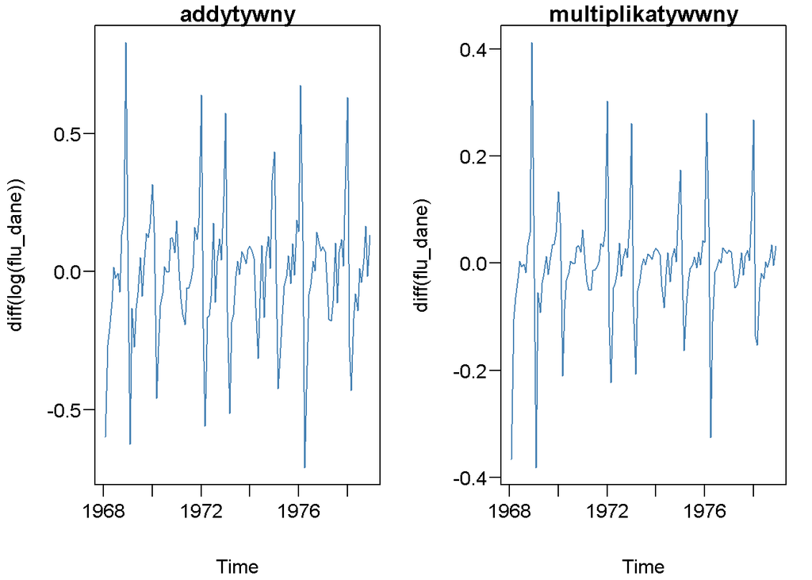

```r
par(mfcol=c(1,2),mar=c(4,4,1,1)+0.1, mgp=c(3,0.6,0),las=1)
plot(diff(log(flu_dane)),col="SteelBlue"); title("addytywny")
plot(diff(flu_dane),col="SteelBlue"); title("multiplikatywwny")
```

Jednokrotne roznicowanie zdecydowanie pokazuje, ze istnieja bardzo duze wahania sezonowe, jednakze sam trend nie jest do konca widoczny,

Dwukrotne roznicowanie szeregow czasowych

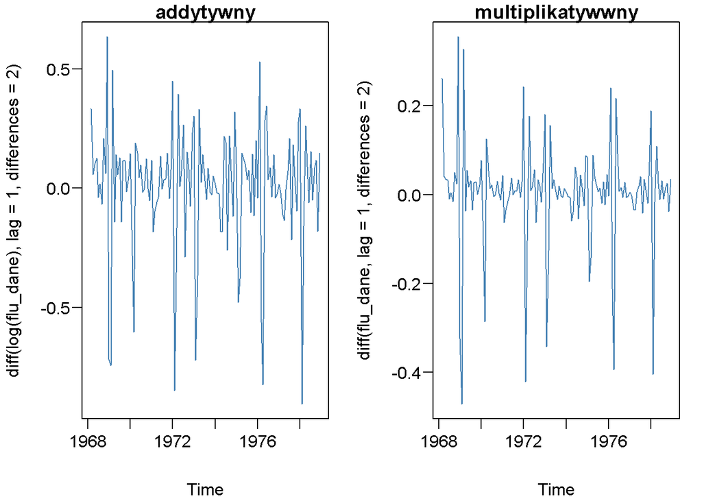

```r
par(mfcol=c(1,2),mar=c(4,4,1,1)+0.1, mgp=c(3,0.6,0),las=1)
plot(diff(log(flu_dane), lag=1, differences = 2),col="SteelBlue"); title("addytywny")
plot(diff(flu_dane, lag=1, differences = 2),col="SteelBlue"); title("multiplikatywwny")
```

Filtr Hodricka-Presscota oraz Cyclical component

```r
library(FRAPO)
```

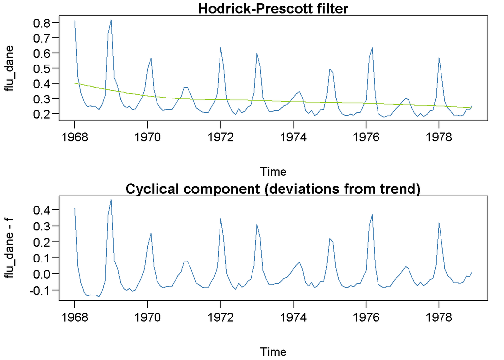

```r
f <- FRAPO::trdhp(flu_dane, lambda=14400)

par(mfcol=c(2,1),mar=c(4,4,1,1)+0.1, mgp=c(3,0.6,0),las=1)
plot(flu_dane,col="SteelBlue",
     main="Hodrick-Prescott filter")

lines(f,col="YellowGreen")
plot(flu_dane-f,col="SteelBlue",
     main="Cyclical component (deviations from trend)")
```

Za pomoca filtru Hodricka-Prescotta mozemy oczyscic dane z wahan periodycznych. Pozwala to nam w tym wypadku zobaczyc pewien malejacy trend, ktory normalnie nie bylby widoczny z tak mocnymi zmianami sezonowymi. Oznacza to tyle, ze opieka zdrowotna w tym okresie poprawila sie, co pomoglo w zmniejszeniu ilosci smierci, a takze lekkim zmniejszeniu wahan sezonowych z roku na rok.

Funkcja autokorelacji ACF

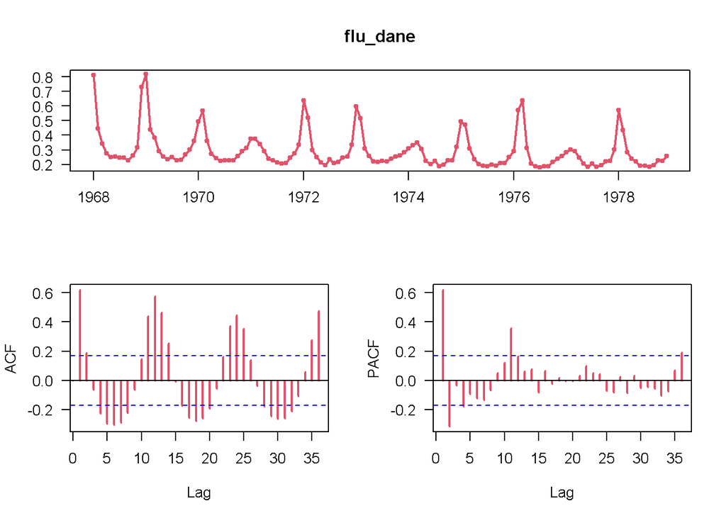

```r
library(forecast)
forecast::tsdisplay(flu_dane,col=2,lwd=2,las=1)
```

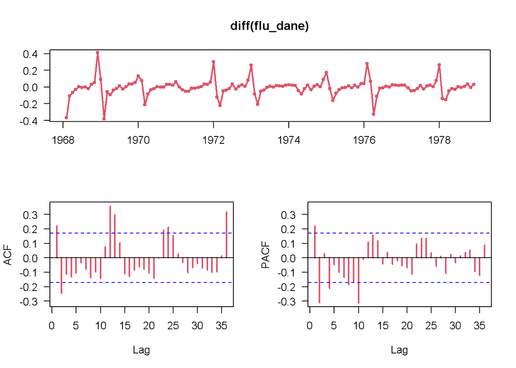

```r
forecast::tsdisplay(diff(flu_dane),col=2,lwd=2,las=1)
```

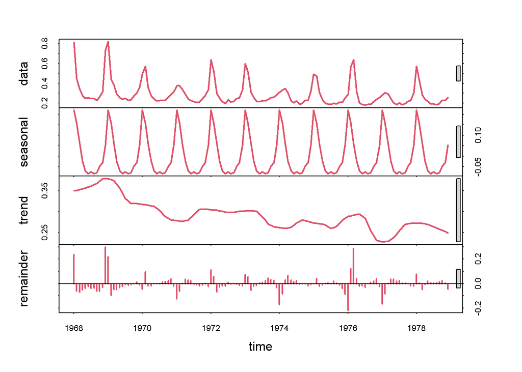

```r
plot(stl(flu_dane,s.window="periodic"),col=2,lwd=2)
```

Funkcja autokorelacji ACF sluzy do identyfikacji skladowych szeregu czasowego( w tym trendu oraz sezonowosci). Funkcje ACF oraz PACF mozemy zobaczyc na samym poczatku. Funkcja autokorelacji nieznacznie zmniejsza sie ze wzrostem parametru, co moze wskazywac na wystepowanie trendu, choc przy takich dosyc malych roznicach moze byc to rownie dobrze blad w danych lub w przewidywaniu. Po usunieciu trendu mozemy bardzo wyraznie zobaczyc wahania sezonowe, ktore rowniez wczesniej byly mocno zaakcentowane w przypadku poprzednich wykresow. Na koncu funkcja “stl” potwierdza jednak zarowno wahania sezonowe(wczesniej juz udowodnione), ale rowniez trend, ktory jest mniej oczywisty, ale jednak wystepujacy(ze sporymi wahaniami)

Modele autoregresyjne ARIMA

```r
m <- forecast::auto.arima(flu_dane,d=1)
summary(m)
```

```
## Series: flu_dane
## ARIMA(0,1,3)(0,1,1)[12]
##
## Coefficients:
##           ma1      ma2     ma3     sma1
##       -0.3176  -0.7332  0.0761  -0.6460
## s.e.   0.1060   0.0781  0.1037   0.1045
##
## sigma^2 estimated as 0.004702:  log likelihood=146.46
## AIC=-282.91   AICc=-282.38   BIC=-269.02
##
## Training set error measures:
##                       ME       RMSE        MAE     MPE     MAPE      MASE
## Training set 0.006808312 0.06400376 0.03654661 1.92954 11.58968 0.7462983
##                    ACF1
## Training set 0.00516885
```

```r
r <- resid(m)
p <- sapply(1:10,function(i) Box.test(r, i, type = "Ljung-Box")$p.value)
p
```

```
##  [1] 0.9521065 0.7478731 0.6288250 0.7576094 0.8244681 0.9005947 0.9457369
##  [8] 0.9659461 0.9829884 0.8904654
```

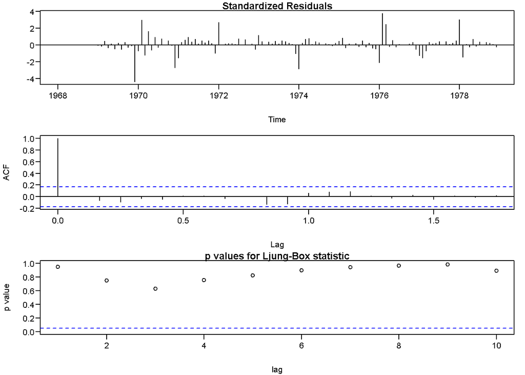

```r
par(mar=c(4,4,1,1)+0.1, mgp=c(3,0.6,0),las=1)
tsdiag(m)
```

```r
forecast::forecast(m,h=12)
```

```
##          Point Forecast      Lo 80     Hi 80       Lo 95     Hi 95
## Jan 1979      0.4051619 0.31715705 0.4931668 0.270570087 0.5397537
## Feb 1979      0.4040428 0.29736930 0.5107163 0.240899753 0.5671859
## Mar 1979      0.3230903 0.21634857 0.4298321 0.159842902 0.4863377
## Apr 1979      0.2325213 0.12575662 0.3392861 0.069238795 0.3958039
## May 1979      0.1880640 0.08127634 0.2948517 0.024746356 0.3513817
## Jun 1979      0.1671946 0.06038393 0.2740052 0.003841792 0.3305474
## Jul 1979      0.1734516 0.06661802 0.2802852 0.010063726 0.3368395
## Aug 1979      0.1648262 0.05796961 0.2716827 0.001403168 0.3282492
## Sep 1979      0.1718419 0.06496237 0.2787214 0.008383773 0.3353000
## Oct 1979      0.2003577 0.09345521 0.3072601 0.036864472 0.3638509
## Nov 1979      0.2055309 0.09860596 0.3124559 0.042003300 0.3690586
## Dec 1979      0.2556021 0.14865095 0.3625532 0.092034444 0.4191697
```

```r
par(mar=c(4,4,1,1)+0.1, mgp=c(3,0.6,0),las=1)
```

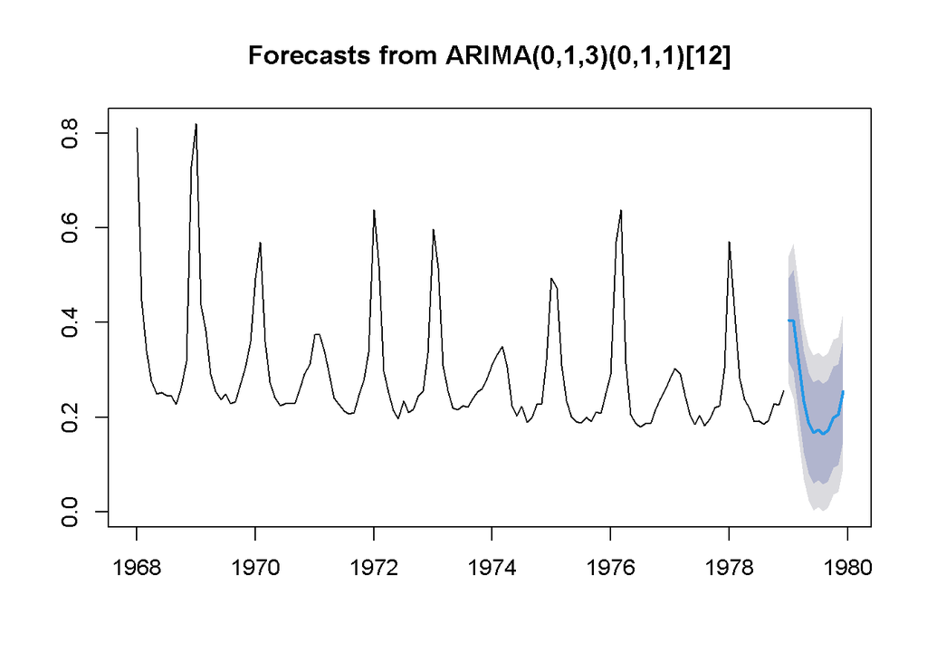

```r
plot(forecast::forecast(m,h=12))
```

```r
p <- predict(m,n.ahead=12)
ts( cbind(pred=p$pred, se=p$se, error=p$se/p$pred), start=c(1979,1),freq=12)
```

```
##               pred         se     error
## Jan 1979 0.4051619 0.06867056 0.1694892
## Feb 1979 0.4040428 0.08323779 0.2060123
## Mar 1979 0.3230903 0.08329102 0.2577949
## Apr 1979 0.2325213 0.08330895 0.3582852
## May 1979 0.1880640 0.08332687 0.4430772
## Jun 1979 0.1671946 0.08334479 0.4984898
## Jul 1979 0.1734516 0.08336271 0.4806107
## Aug 1979 0.1648262 0.08338062 0.5058700
## Sep 1979 0.1718419 0.08339853 0.4853213
## Oct 1979 0.2003577 0.08341643 0.4163376
## Nov 1979 0.2055309 0.08343400 0.4059438
## Dec 1979 0.2556021 0.08345440 0.3265013
```

Na samym koncu za pomoca funkcji “forecast” mozna tworzyc prognozy na podstawie modelu. W moim przypadku zdecydowalem sie na rok 1979. Po zastosowaniu funkcji mozemy zobaczyc na wykresie oraz w zwyklych danych jakie sa przewidywania modelu oraz jaki jest blad modelu. Najlepsze predykcje przypadaja na poczatek roku, podczas gdy najgorsze przewidywania sa mniej wiecej w srodku roku. Model zdecydowanie mniej sie myli kiedy ma do czynienia z wahaniami sezonowymi, podczas gdy okresy “spokoju” sa dla niego bardziej klopotliwe i ma mniejsze pojecie o tym jak sobie z nimi poradzic.